# Análise Inteligente dos Dados (Yuri AT)

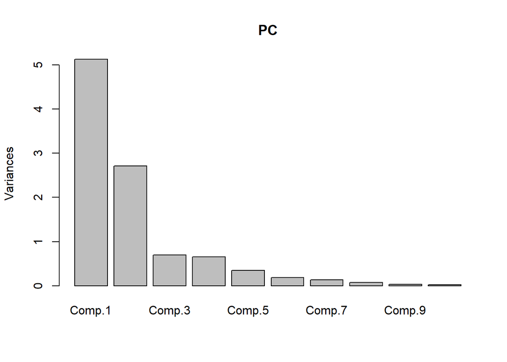

```r
screeplot(PC) # No. CPs relevantes
```

```r
print(PC$loadings)
```

```
##
## Loadings:
##                   Comp.1 Comp.2 Comp.3 Comp.4 Comp.5 Comp.6 Comp.7 Comp.8
## incidencia16p      0.322  0.264         0.141  0.862         0.172
## dispensa16p        0.332 -0.327  0.218                0.560 -0.567  0.252
## farmacia16p        0.235 -0.434 -0.422                0.319  0.640
## ensino16p          0.289 -0.408  0.193               -0.639        -0.161
## infraestrutura16p  0.327 -0.392                      -0.201
## habilita16         0.290         0.106  0.901 -0.274               -0.104
## IDHM_renda16       0.354  0.309  0.200 -0.209         0.114        -0.540
## IDHM_logevidade16  0.358  0.286        -0.281 -0.348  0.154        -0.197
## IDHM_educacao16    0.348  0.319  0.172        -0.203 -0.242  0.185  0.749
## gini16            -0.285 -0.189  0.807                0.186  0.433
##                   Comp.9 Comp.10
## incidencia16p      0.157
## dispensa16p       -0.108  0.119
## farmacia16p       -0.193  0.123
## ensino16p         -0.157  0.484
## infraestrutura16p  0.400 -0.723
## habilita16
## IDHM_renda16      -0.557 -0.263
## IDHM_logevidade16  0.625  0.358
## IDHM_educacao16   -0.184
## gini16
##
##                Comp.1 Comp.2 Comp.3 Comp.4 Comp.5 Comp.6 Comp.7 Comp.8 Comp.9
## SS loadings       1.0    1.0    1.0    1.0    1.0    1.0    1.0    1.0    1.0
## Proportion Var    0.1    0.1    0.1    0.1    0.1    0.1    0.1    0.1    0.1
## Cumulative Var    0.1    0.2    0.3    0.4    0.5    0.6    0.7    0.8    0.9
##                Comp.10
## SS loadings        1.0
## Proportion Var     0.1
## Cumulative Var     1.0
```

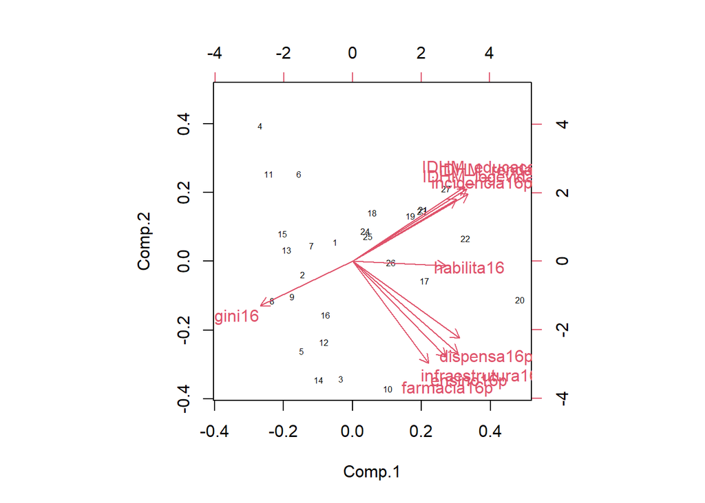

```r
biplot (PC, cex= c(.5,1))
```

```r
### PCA - prcomp()
PrC <- prcomp(log_hcvdata16[7:16], retx = FALSE, center = TRUE, scale. = TRUE,
              tol = NULL, rank. = 5)
PrC$rotation
```

```
##                          PC1         PC2         PC3         PC4         PC5
## incidencia16p     -0.3218188  0.26449873 -0.03564261  0.14083688 -0.86150679
## dispensa16p       -0.3317852 -0.32651079 -0.21759988 -0.08240154 -0.06462018
## farmacia16p       -0.2351649 -0.43351480  0.42198073 -0.09637773  0.04626016
## ensino16p         -0.2887846 -0.40841365 -0.19303547 -0.09799664 -0.07039670
## infraestrutura16p -0.3270742 -0.39242327 -0.04233414 -0.09708005 -0.01653404
## habilita16        -0.2901064 -0.01805727 -0.10646001  0.90099174  0.27424663
## IDHM_renda16      -0.3541940  0.30902182 -0.19999266 -0.20937446  0.09106109
## IDHM_logevidade16 -0.3581775  0.28585172 -0.04105257 -0.28129833  0.34782409
## IDHM_educacao16   -0.3484499  0.31878596 -0.17166550 -0.09392134  0.20317450
## gini16             0.2852210 -0.18852603 -0.80732406 -0.03853138 -0.02228023
```

```r
# Salvar  as 5 componentes principais
#2016
cph16 <<- within(rl16, {
  PC5_incidencia <- PC$scores[,5]
  PC4_habilitacao <- PC$scores[,4]
  PC3_gini <- PC$scores[,3]
  PC2_estrutural <- PC$scores[,2]
  PC1_social <- PC$scores[,1]})
cph16 <- cph16[, -c(2:11)]

#2017
PC17 <- princomp(rl17[3:12],cor=TRUE, scores=TRUE, fix_sign=TRUE)
cph17 <<- within(rl17, {
  PC17_5_incidencia <- PC17$scores[,5]
  PC17_4_habilitacao <- PC17$scores[,4]
  PC17_3_gini <- PC17$scores[,3]
  PC17_2_estrutural <- PC17$scores[,2]
  PC17_1_social <- PC17$scores[,1]})
cph17 <- cph17[, -c(2:11)]
```

A PCA indica que separar os IDHM por renda, longevidade e educação não seria relevante, e que as variáveis coeficiente de Gini, taxa de farmácias especializadas, taxa de infraestrutura, número de centro habilitados e dispensação são as variáveis que melhor explicam os principais componentes. Podemos então trabalhar com as componentes salvas para a modelagem.

######Componentes salvas

1. PC1_social = impactada pelos IDH’s estaduais (explica 0.51)
2. PC2_estrutural = impactada pelo log das taxas de dispensação, farmácias, centros de ensino especializados e infraestrura geral (explica 0.27)
3. PC3_gini = impactada principalmente pelo coeficiente de Gini (explica 0.07)
4. PC4_habilitacao = impactada principalmente pelos centros habilitados à realizar testes para o HCV (explica 0.06)
5. PC5_incidencia = impactado pelo log da taxa de incidência (explica 0.03)

####Regressão linear com componentes principais

```r
modelocp = lm(cph16$obitos16p ~., data=cph16)
summary(modelocp)
```

```
##
## Call:
## lm(formula = cph16$obitos16p ~ ., data = cph16)
##
## Residuals:
##      Min       1Q   Median       3Q      Max
## -0.58856 -0.10793 -0.00491  0.20083  0.55929
##
## Coefficients:
##                 Estimate Std. Error t value Pr(>|t|)
## (Intercept)      0.99964    0.25567   3.910  0.00113 **
## regiao16NE      -0.62877    0.41102  -1.530  0.14447
## regiao16NO      -0.35760    0.34287  -1.043  0.31157
## regiao16SE       0.09718    0.30579   0.318  0.75450
## regiao16SU       0.26551    0.34213   0.776  0.44837
## PC1_social      -0.04299    0.07485  -0.574  0.57326
## PC2_estrutural  -0.08151    0.05827  -1.399  0.17983
## PC3_gini         0.05458    0.09241   0.591  0.56254
## PC4_habilitacao  0.07547    0.10413   0.725  0.47847
## PC5_incidencia   0.19839    0.13012   1.525  0.14571
## ---
## Signif. codes:  0 '***' 0.001 '**' 0.01 '*' 0.05 '.' 0.1 ' ' 1
##
## Residual standard error: 0.3414 on 17 degrees of freedom
## Multiple R-squared:  0.4085, Adjusted R-squared:  0.09542
## F-statistic: 1.305 on 9 and 17 DF,  p-value: 0.3039
```

```r
#ANOVA do modelo
anova(modelocp)
```

```
## Analysis of Variance Table
##
## Response: cph16$obitos16p
##                 Df  Sum Sq  Mean Sq F value Pr(>F)
## regiao16         4 0.89293 0.223231  1.9153 0.1541
## PC1_social       1 0.04443 0.044430  0.3812 0.5451
## PC2_estrutural   1 0.09266 0.092658  0.7950 0.3850
## PC3_gini         1 0.04311 0.043110  0.3699 0.5511
## PC4_habilitacao  1 0.02452 0.024519  0.2104 0.6523
## PC5_incidencia   1 0.27096 0.270958  2.3248 0.1457
## Residuals       17 1.98136 0.116550
```

```r
## Importância das variáveis
varImp(modelocp)
```

```
##                   Overall
## regiao16NE      1.5297710
## regiao16NO      1.0429704
## regiao16SE      0.3178045
## regiao16SU      0.7760666
## PC1_social      0.5743360
## PC2_estrutural  1.3988681
## PC3_gini        0.5906270
## PC4_habilitacao 0.7247334
## PC5_incidencia  1.5247333
```

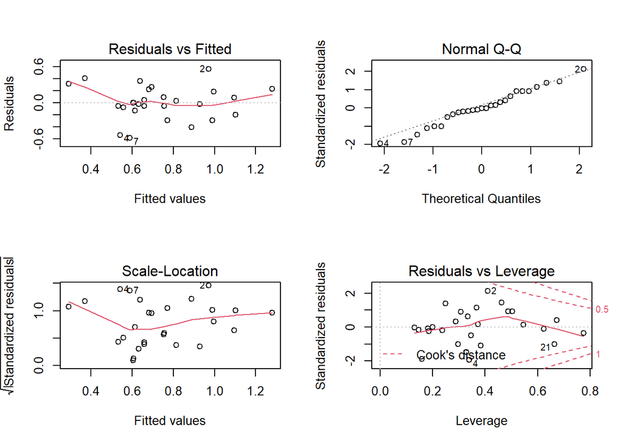

[figure not shown]

[output not shown]

[output not shown]

```r
par(mfrow=c(2,2))
plot(modelocp)
```

O r² ajustado da regressão linear múltipla com as componentes principais demonstra que essas não parecem explicar o índice de mortalidade. Logo, podemos observar que a covariância entre as variavéis que compõem o modelo, quando tratadas separadamente (como nas regressões anteriores) geram resultados díspares.

###Árvore de regressão A árvore de regressão para variáveis de saída numéricas possui fórmula similar a utilizada nas regressões acima, contudo através dela também podemos analisar o impacto de fatores não numéricos (como as regiões) e ter uma visão mais gráfica das subdivisões geradas pela variação nos dados. Na construção do gráfico da árvore cada ramo apresenta a porcentagem de variáveis contidas naquele ramo que apresentam a mesma média na variável resposta, de forma crescente.

#####Árvore com banco de dados de 2016 completo

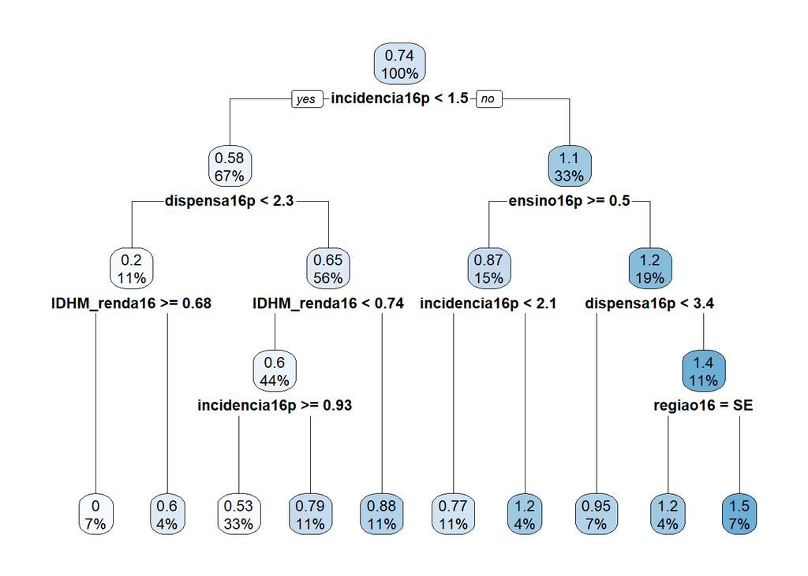

```r
fit <- rpart(rl16$obitos16p~ .,
             method="anova", data=rl16, minsplit = 2, minbucket = 1)
rpart.plot(fit)
```

```r
summary(fit)
```

```
## Call:
## rpart(formula = rl16$obitos16p ~ ., data = rl16, method = "anova",
##     minsplit = 2, minbucket = 1)
##   n= 27
##
##            CP nsplit  rel error    xerror      xstd
## 1  0.42471839      0 1.00000000 1.0943600 0.3318306
## 2  0.15373834      1 0.57528161 0.9367577 0.3072983
## 3  0.08307385      2 0.42154327 1.0699520 0.2850774
## 4  0.07340968      3 0.33846942 1.1613438 0.2932710
## 5  0.07213547      4 0.26505974 1.1243693 0.2881664
## 6  0.05763829      5 0.19292427 1.2428105 0.2888468
## 7  0.04566733      6 0.13528598 1.3169170 0.3113675
## 8  0.03746632      7 0.08961865 1.3164854 0.3070725
## 9  0.02330710      8 0.05215233 1.1624064 0.2515405
## 10 0.01000000      9 0.02884524 1.2083458 0.2684595
##
## Variable importance
##     incidencia16p      IDHM_renda16 IDHM_logevidade16   IDHM_educacao16
##                16                15                13                11
##       dispensa16p          regiao16         ensino16p        habilita16
##                 9                 9                 7                 6
## infraestrutura16p       farmacia16p            gini16
##                 6                 5                 2
##
## Node number 1: 27 observations,    complexity param=0.4247184
##   mean=0.7412403, MSE=0.1240725
##   left son=2 (18 obs) right son=3 (9 obs)
##   Primary splits:
##       incidencia16p     < 1.497818   to the left,  improve=0.4247184, (0 missing)
##       dispensa16p       < 2.349971   to the left,  improve=0.3115434, (0 missing)
##       IDHM_renda16      < 0.736      to the left,  improve=0.2714346, (0 missing)
##       IDHM_logevidade16 < 0.824      to the left,  improve=0.2493839, (0 missing)
##       gini16            < 0.595      to the right, improve=0.2486980, (0 missing)
##   Surrogate splits:
##       IDHM_renda16      < 0.75       to the left,  agree=0.889, adj=0.667, (0 split)
##       regiao16          splits as  LLLRR, agree=0.852, adj=0.556, (0 split)
##       IDHM_logevidade16 < 0.8285     to the left,  agree=0.852, adj=0.556, (0 split)
##       IDHM_educacao16   < 0.6365     to the left,  agree=0.852, adj=0.556, (0 split)
##       habilita16        < 3.5        to the left,  agree=0.815, adj=0.444, (0 split)
```

[output cut: 116 more lines]

```
##       ensino16p    < 0.3526089  to the right, improve=0.9955804, (0 missing)
##       habilita16   < 3.5        to the right, improve=0.9955804, (0 missing)
##       IDHM_renda16 < 0.7755     to the right, improve=0.9955804, (0 missing)
##
## Node number 20: 9 observations
##   mean=0.5326496, MSE=0.003854244
##
## Node number 21: 3 observations
##   mean=0.7934037, MSE=0.007060481
##
## Node number 30: 1 observations
##   mean=1.176091, MSE=0
##
## Node number 31: 2 observations
##   mean=1.518314, MSE=0.0001733033
```